# Recognizing Weight Lifting Quality - PML Project

rfalcon

Wednesday, September 22, 2015

# Executive summary

# Analysis and discussion

## 1. Getting and cleaning data

We read the training and test sets as CSV files. Notice that missing values are denoted by either blank entries or those with “NA” or “#DIV/0!”.

```r
dataSet <- read.csv("pml-training.csv", na.strings = c("NA", "#DIV/0!", ""))
validationSet <- read.csv("pml-testing.csv", na.strings = c("NA", "#DIV/0!", ""))
rbind(dim(dataSet), dim(validationSet))
```

```
##       [,1] [,2]
## [1,] 19622  160
## [2,]    20  160
```

Then we remove those columns that only contain missing values:

```r
dataSet <- dataSet[,colSums(is.na(dataSet)) == 0]
validationSet <- validationSet[,colSums(is.na(validationSet)) == 0]
rbind(dim(dataSet), dim(validationSet))
```

```
##       [,1] [,2]
## [1,] 19622   60
## [2,]    20   60
```

This step dramatically shortened the number of features from 160 to 60. As shown below, no other feature in either dataset has missing values.

```r
c(any(colSums(is.na(dataSet)) > 0),any(colSums(is.na(validationSet)) > 0))
```

```
## [1] FALSE FALSE
```

Next, we remove the first 7 features in the dataset as these are housekeeping features like user_name, raw_timestamp, etc. Although this is time series data, our validation set only consists of individual snapshots; hence, it is better to treat each record as an independent entry for prediction purposes.

```r
dataSet <- dataSet[,-(1:7)]
dim(dataSet)
```

```
## [1] 19622    53
```

Next, we remove the 4 summary features that start with “total”, since any predictive information they contain is already embodied in the measurement data.

```r
dataSet <- dataSet[,-grep("total",names(dataSet))]
dim(dataSet)
```

```
## [1] 19622    49
```

At this point, there are no near-zero-variance features in the dataset that could be further removed.

```r
library(caret)
any(nearZeroVar(dataSet))
```

```
## [1] FALSE
```

Additionally, all predictive features are numeric (including integers) and none has a nominal nature.

```r
unique(sapply(dataSet[,-49], class))
```

```
## [1] "numeric" "integer"
```

We have narrowed down our data from 160 to 49 features. Yet it is still possible to remove redundant features and thus simplify the downstream model. Let us try removing those features that are highly correlated with one another.

```r
correlationMatrix <- cor(dataSet[,-49])
highlyCorrelated <- findCorrelation(correlationMatrix, cutoff=0.8)
highlyCorrelated
```

```
##  [1]  9  1 33  7  2 19 31 23 28 41 30 16
```

```r
dataSet <- dataSet[,-highlyCorrelated]
dim(dataSet)
```

```
## [1] 19622    37
```

## 2. Data slicing

Let us slice the dataset into 75% training data and 25% for testing. We will build different models on the training data via repeated 10-fold cross validation and evaluate their performance on the test data.

```r
inTrain <- createDataPartition(y=dataSet$classe, p=0.75, list=FALSE)
trainingSet <- dataSet[inTrain,]
testingSet <- dataSet[-inTrain,]
```

## 3. Feature selection

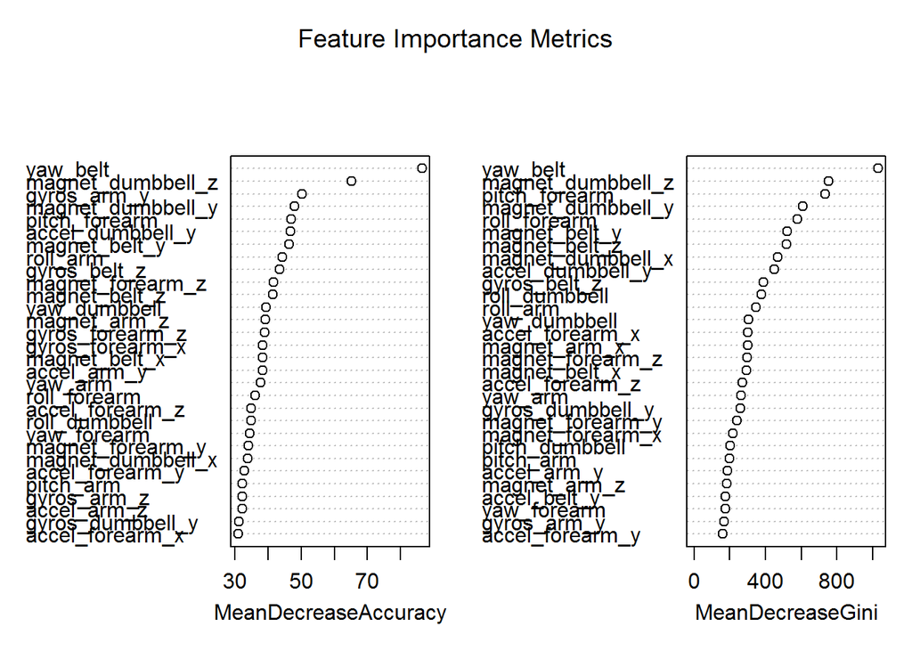

```r
library(randomForest)
library(ggplot2)

if (file.exists("rffs.mda")) {
  load("rffs.mda")
} else {
  mdlRFFS <- randomForest(classe ~ ., data=trainingSet, mtry=6, importance=TRUE)
  save(mdlRFFS, file="rffs.mda")
}

featureImportance <- importance(mdlRFFS)
varImpPlot(mdlRFFS, main="Feature Importance Metrics")
```

**Fig. 1. Feature importance as determined by a random forest of 500 trees**

We will take the average rank of each feature across both metrics to decide on their importance as we want to retain features with high discriminatory power that also contributed to purer nodes.

```r
library(knitr)
featureRanks <- sort((rank(1/featureImportance[,6]) + rank(1/featureImportance[,7]))/2)
kable(data.frame(rank = featureRanks), format = "html")
```

|  | rank |
| --- | --- |
| yaw_belt | 1.0 |
| magnet_dumbbell_z | 2.0 |
| magnet_dumbbell_y | 4.0 |
| pitch_forearm | 4.0 |
| magnet_belt_y | 6.5 |
| accel_dumbbell_y | 7.5 |
| magnet_belt_z | 9.0 |
| gyros_belt_z | 9.5 |
| roll_arm | 10.0 |
| roll_forearm | 12.0 |
| yaw_dumbbell | 12.5 |
| magnet_forearm_z | 13.0 |
| gyros_arm_y | 16.0 |
| roll_dumbbell | 16.0 |
| magnet_dumbbell_x | 16.0 |
| magnet_belt_x | 16.5 |
| yaw_arm | 18.5 |
| accel_forearm_z | 19.0 |
| magnet_arm_z | 19.5 |
| accel_arm_y | 21.0 |
| accel_forearm_x | 22.0 |
| magnet_forearm_y | 22.0 |
| gyros_forearm_z | 24.0 |
| magnet_arm_x | 24.5 |
| gyros_dumbbell_y | 24.5 |
| pitch_arm | 25.0 |
| yaw_forearm | 25.0 |
| gyros_forearm_x | 25.0 |
| accel_forearm_y | 27.5 |
| magnet_forearm_x | 28.5 |
| accel_arm_z | 29.5 |
| pitch_dumbbell | 29.5 |
| accel_belt_y | 30.0 |
| gyros_arm_z | 31.5 |
| gyros_belt_x | 32.0 |
| gyros_belt_y | 32.0 |

We will build our model with the top 25% ranked features, as shown below:

```r
selectedFeatures <- featureRanks[featureRanks <= quantile(featureRanks)[2]]
trainingSet <- trainingSet[, c(names(selectedFeatures), "classe")]
kable(data.frame(selectedFeatures))
```

|  | selectedFeatures |
| --- | --- |
| yaw_belt | 1.0 |
| magnet_dumbbell_z | 2.0 |
| magnet_dumbbell_y | 4.0 |
| pitch_forearm | 4.0 |
| magnet_belt_y | 6.5 |
| accel_dumbbell_y | 7.5 |
| magnet_belt_z | 9.0 |
| gyros_belt_z | 9.5 |
| roll_arm | 10.0 |

## 4. Model selection

For the experimental analysis, we have selected 13 different classification models belonging to 7 different families, as shown below:

1. bagging models (Random Forests *RF*, Weighted Subspace Random Forest *WSRF*)
2. boosting models (*ADA*, *AdaBoost*, *BoostedTree*)
3. decision tree models (*C5.0*)
4. prototype-based models (Learning Vector Quantization *LVQ*)
5. neural network models (Multilayer Perceptron *MLP*, Radial Basis Function Neural Network *RBFN*, Stacked Autoencoder Deep Neural Network *DNN*)
6. instance-based models (K Nearest Neighbor *KNN*)
7. kernel-based models (Least-Squares Support Vector Machine with Radial Basis Function Kernel *LSSVMRadial*, Support Vector Machine with Polynomial Kernel *SVMPoly* )

The out-of-sample error is estimated via repeating 10-fold cross validation over the training set 3 times. The *train* function in the *caret* package allows selecting the most suitable parametric configuration for each model using a grid-search approach. By default, the best parametric configuration is the one that maximizes the underlying performance metric, *classification accuracy* in this case.

The following table contains the performance metrics (in terms of classification accuracy, its 95% confidence interval and the Kappa statistic) of all classifiers under consideration.

[output not shown]

Notice that all the decision-tree-based models except the boosted tree (i.e., RF, WSRF and C5.0) achieved very high classification accuracy rates (above 97% and with robust 95% confidence intervals) and that the three neural-network-based models performed really poorly. It is worthwhile noticing that KNN with k = 5 attained 93% accuracy despite the lack of any training process for this lazy learner. Ada and AdaBoost did slightly better than the two SVM-based methods.

|  | OutOfSampleError |
| --- | --- |
| RF | 0.0265090 |
| WSRF | 0.0291599 |
| Ada | 0.1294861 |
| AdaBoost | 0.1294861 |
| BoostedTree | 0.6180669 |
| C5.0 | 0.0261011 |
| LVQ | 0.4424959 |
| MLP | 0.7155383 |
| RBFN | 0.7137031 |
| DNN | 0.7112561 |
| KNN | 0.0668842 |
| LSSVMRadial | 0.1977977 |
| SVMPoly | 0.1435563 |

## Results

Well, BoostedTree nailed the instance #1 but none of the 13 classifiers under consideration were able to suggest another class for instance 14 other than ‘A’.